## Spatial Trends in Surficial Sediment

Twenty surficial sediment cores ranging from 6-12 cm thick were analyzed for grain size, laminae thickness, and organic content. These samples were collected following a longitudinal transect down Cariboo Lake and indicate how sediment flux varies with distance from the Cariboo River delta (see Figure @ref(fig:map-lake), for sampling locations, n = 20). Proximal to the Cariboo River delta (< 500 m) the structure of the surficial sediments exhibits massive layering, erosive contacts and the fraction of sand grains in these samples is greater than 60%. A sand-bed with a thickness of 1 cm is observed in the bulk sample closest to the Cariboo River delta (Figure @ref(fig:ekmanImgs), A). The D50 grain size follows a steep decline from 89.9 µm, 300 m from the delta, to 31.3 µm 550 m from the Cariboo River delta (Figure @ref(fig:ekmanSeds)). The decline in D90 grain size follows a more pronounced decline, while the D10 does remains largely unchanged. This suggests that larger sand-sized sediments are sensitive to distance from fan deltas, while smaller silt- and clay-sized sediments are less sensitive. The decrease in D50/D90 grain size generally continues further down-lake with the exception to samples proximal to valley-side fan-deltas. A small increase in D50 is observed proximal to the Pine Creek fan-delta from a low of 21.5 µm at 1.1 km, up to 28.2 µm 1.83 km from the main Cariboo River delta (Figure @ref(fig:ekmanSeds)). At distances greater than 2 km from the Cariboo River delta the fraction of silt-sized sediments remains over 80 %, aside from core E16 which is near the Frank Creek fan-delta. Proximal to the Frank Creek fan-delta the D50 grain size nearly doubles in size from 7.92 µm at 6.4 km to 15.1 µm at 7.35 km from the Cariboo River delta. In the main Cariboo River sub-basin, the most well-preserved core was taken 5.24 km from the Cariboo River delta in the deepest part of the sub-basin at a depth of 40 m and shows rhythmically laminated sediments (Figure @ref(fig:ekmanImgs), B). In the Keithley Creek basin the D50 grain size has an average of 15.9 µm (n = 3) and the composition of sediment 4.0% clay, 85.8% silt, and 10.2% sand (Figure @ref(fig:ekmanSeds)).

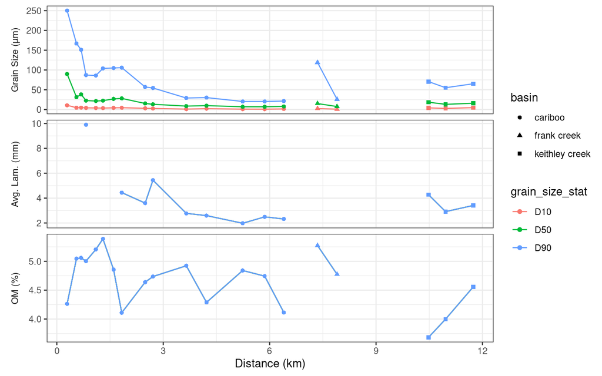

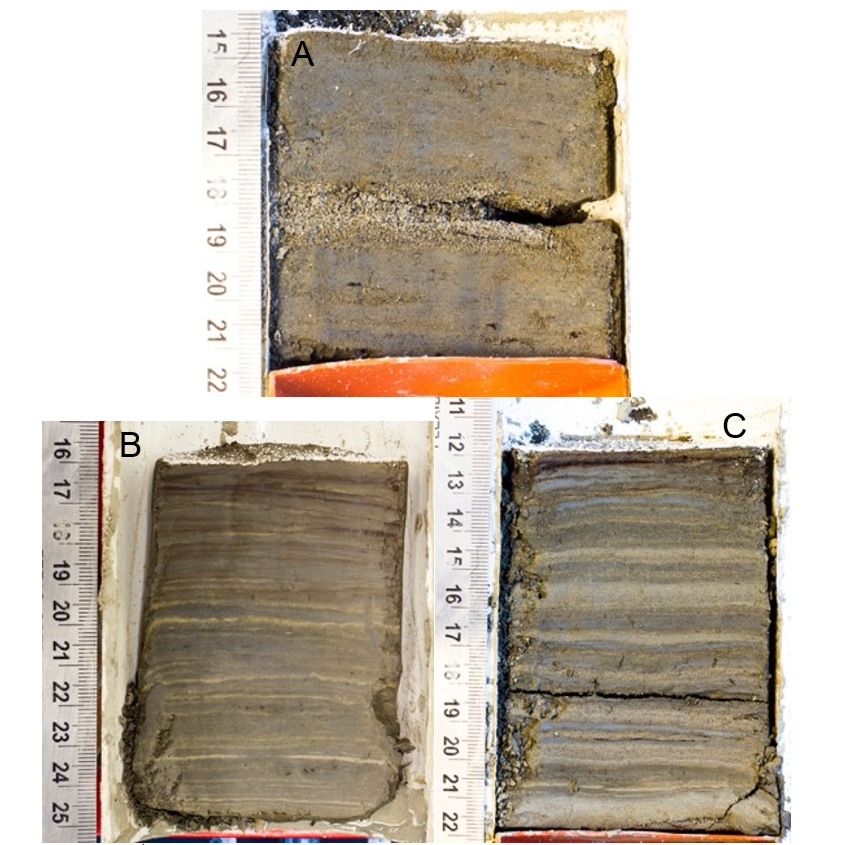

Sediment cores E9-E15 and E18-E20, retrieved from areas in Cariboo Lake that are distal from river deltas and have lake depths of 30-50 m, have a high fraction of silt and clay sediment and exhibit a sequence of fine-grained dark layers followed by coarse-grained light layers (Figure @ref(fig:ekmanImgs), B & C). The thickness of sediment laminae within these surface cores demonstrate a gradual decreasing trend with distance down-lake from the Cariboo River delta (Figure @ref(fig:ekmanSeds)). Maximum laminae thickness has an average of 4.7 mm (n = 6) in the Cariboo River basin and 7.9 mm (n = 3) in the Keithley Creek basin. In the Cariboo River basin, maximum varve thickness decreases by 0.62 mm/km and by 2.17 mm/km in the Keithley Creek basin with distance down-lake (Figure @ref(fig:ekmanSeds)). This decrease in laminae thickness with distance from the main contributing delta’s is attributed to the Cariboo River being the main source of sediment into Cariboo Lake as sediment flux typically declines with distance from the primary sediment source. The decline in thickness is steeper in the Keithley Creek Basin is likely due to additional local inputs of coarser grained sediment coming from the Keithley Creek tributary which are not transported as far as suspended sediments.

Trends in percent organic matter of surficial sediment cores where not found to exhibit systematic patterns with distance down-lake (Figure @ref(fig:ekmanSeds)). However, higher OM values were observed close to the main Cariboo River delta, likely due to the relatively low levels of erosion and high levels of allochthonous organic matter entering the lake. The lowest OM values were observed in the Keithley Creek basin which suggest higher levels of clastic sediment yield in this basin.